#### Dragos Ailoae

2021-11-15

# Regression with Binary Dependent Variables

Instead of using a continuous regressor $X$, we might be interested in running the regression $$ Y_{i}=\beta_{0}+\beta_{1} D_{i}+u_{i} $$ where $D_{i}$ is a binary variable, a so-called dummy variable.

For an example, let's look at the California Test Score dataset available via the AER package. We may define $D_{i}$ based on the students-teacher-ratio (STR) as follows: $$ D_{i}= \begin{cases}1 & \text { if } S T R \text { in } i^{t h} \text { school district }<20 \\ 0 & \text { if } S T R \text { in } i^{t h} \text { school district } \geq 20\end{cases} $$

Then we may then want to look at the following regression model: $$ \text { TestScore }_{i}=\beta_{0}+\beta_{1} D_{i}+u_{i} $$

Let's begin by loading and setting up our data:

```r
options(warn=-1) # Suppress warnings
qui <- suppressPackageStartupMessages # quiet! - suppress library load messages
# install (if not already installed) and load package
qui(if(!require(AER)){install.packages('AER')})  # for CASchools dataset

data(CASchools)    # Load dataset
df <- CASchools    # store in local dataframe

df$STR <- df$students/df$teachers  # calculate student to teacher ratio
df$score <- (df$read + df$math)/2  # calculate average scores

# Create the dummy variable as defined above
df$D <- df$STR < 20

# show data
head(df)
tail(df)
```

| district | school | county | grades | students | teachers | calworks | lunch | computer | expenditure | income | english | read | math | STR | score | D |
| --- | --- | --- | --- | --- | --- | --- | --- | --- | --- | --- | --- | --- | --- | --- | --- | --- |
| 75119 | Sunol Glen Unified | Alameda | KK-08 | 195 | 10.90 | 0.5102 | 2.0408 | 67 | 6384.911 | 22.690001 | 0.000000 | 691.6 | 690.0 | 17.88991 | 690.80 | TRUE |
| 61499 | Manzanita Elementary | Butte | KK-08 | 240 | 11.15 | 15.4167 | 47.9167 | 101 | 5099.381 | 9.824000 | 4.583333 | 660.5 | 661.9 | 21.52466 | 661.20 | FALSE |
| 61549 | Thermalito Union Elementary | Butte | KK-08 | 1550 | 82.90 | 55.0323 | 76.3226 | 169 | 5501.955 | 8.978000 | 30.000002 | 636.3 | 650.9 | 18.69723 | 643.60 | TRUE |
| 61457 | Golden Feather Union Elementary | Butte | KK-08 | 243 | 14.00 | 36.4754 | 77.0492 | 85 | 7101.831 | 8.978000 | 0.000000 | 651.9 | 643.5 | 17.35714 | 647.70 | TRUE |
| 61523 | Palermo Union Elementary | Butte | KK-08 | 1335 | 71.50 | 33.1086 | 78.4270 | 171 | 5235.988 | 9.080333 | 13.857677 | 641.8 | 639.9 | 18.67133 | 640.85 | TRUE |
| 62042 | Burrel Union Elementary | Fresno | KK-08 | 137 | 6.40 | 12.3188 | 86.9565 | 25 | 5580.147 | 10.415000 | 12.408759 | 605.7 | 605.4 | 21.40625 | 605.55 | FALSE |

|  | district | school | county | grades | students | teachers | calworks | lunch | computer | expenditure | income | english | read | math | STR | score | D |
| --- | --- | --- | --- | --- | --- | --- | --- | --- | --- | --- | --- | --- | --- | --- | --- | --- | --- |
| 415 | 69682 | Saratoga Union Elementary | Santa Clara | KK-08 | 2341 | 124.09 | 0.1709 | 0.5980 | 286 | 5392.639 | 40.40200 | 2.050406 | 698.9 | 701.7 | 18.86534 | 700.30 | TRUE |
| 416 | 68957 | Las Lomitas Elementary | San Mateo | KK-08 | 984 | 59.73 | 0.1016 | 3.5569 | 195 | 7290.339 | 28.71700 | 5.995935 | 700.9 | 707.7 | 16.47413 | 704.30 | TRUE |
| 417 | 69518 | Los Altos Elementary | Santa Clara | KK-08 | 3724 | 208.48 | 1.0741 | 1.5038 | 721 | 5741.463 | 41.73411 | 4.726101 | 704.0 | 709.5 | 17.86263 | 706.75 | TRUE |
| 418 | 72611 | Somis Union Elementary | Ventura | KK-08 | 441 | 20.15 | 3.5635 | 37.1938 | 45 | 4402.832 | 23.73300 | 24.263039 | 648.3 | 641.7 | 21.88586 | 645.00 | FALSE |
| 419 | 72744 | Plumas Elementary | Yuba | KK-08 | 101 | 5.00 | 11.8812 | 59.4059 | 14 | 4776.336 | 9.95200 | 2.970297 | 667.9 | 676.5 | 20.20000 | 672.20 | FALSE |
| 420 | 72751 | Wheatland Elementary | Yuba | KK-08 | 1778 | 93.40 | 6.9235 | 47.5712 | 313 | 5993.393 | 12.50200 | 5.005624 | 660.5 | 651.0 | 19.03640 | 655.75 | TRUE |

We can now plot the relevant data of test scores vs. student-teacher-ratio.

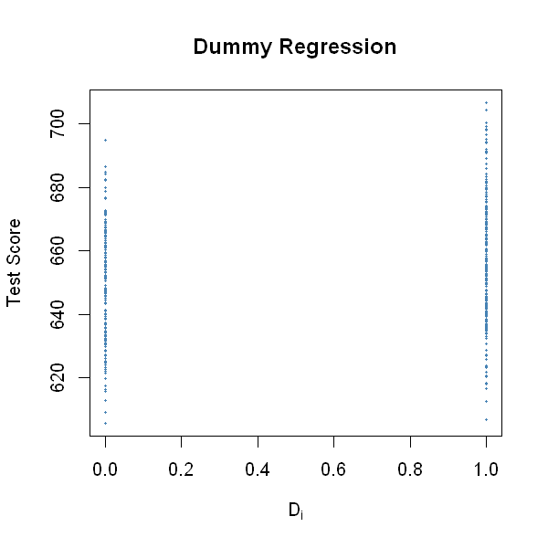

```r
# Plot the data
options(repr.plot.width = 5, repr.plot.height = 5)
plot(df$D, df$score,                          # data to be plotted
     pch = 20,                                # use filled circles as plot symbols
     cex = 0.5,                               # set size of plot symbols to 0.5
     col = "Steelblue",                       # set the symbols' color to "Steelblue"
     xlab = expression(D[i]),                 # Set title and axis names
     ylab = "Test Score",
     main = "Dummy Regression")
```

With $D$ as the regressor, it is not useful to think of $\beta_{1}$ as a slope parameter since $D_{i} \in\{0,1\}$, i.e., we only observe two discrete values instead of a continuum of regressor values. There is no continuous line depicting the conditional expectation function $E\left(\right.$ TestScore $\left._{i} \mid D_{i}\right)$ since this function is solely defined for $x$-positions 0 and 1 . Therefore, the interpretation of the coefficients in this regression model is as follows:

- $E\left(Y_{i} \mid D_{i}=0\right)=\beta_{0}$, so $\beta_{0}$ is the expected test score in districts where $D_{i}=0$ where $S T R$ is above 20
- $E\left(Y_{i} \mid D_{i}=1\right)=\beta_{0}+\beta_{1}$ or, using the result above, $\beta_{1}=E\left(Y_{i} \mid D_{i}=1\right)-E\left(Y_{i} \mid D_{i}=0\right)$. Thus, $\beta_{1}$ is the difference in group-specific expectations, i.e., the difference in expected test score between districts with $S T R<20$ and those with $S T R \geq 20$

We will now use R to estimate the dummy regression model:

```r
# estimate the dummy regression model
dummy_model <- lm(score ~ D, data = df)
summary(dummy_model)
```

```
Call:
lm(formula = score ~ D, data = df)

Residuals:
    Min      1Q  Median      3Q     Max
-50.496 -14.029  -0.346  12.884  49.504

Coefficients:
            Estimate Std. Error t value Pr(>|t|)
(Intercept)  650.077      1.393 466.666  < 2e-16 ***
DTRUE          7.169      1.847   3.882  0.00012 ***
---
Signif. codes:  0 '***' 0.001 '**' 0.01 '*' 0.05 '.' 0.1 ' ' 1

Residual standard error: 18.74 on 418 degrees of freedom
Multiple R-squared:  0.0348,	Adjusted R-squared:  0.0325
F-statistic: 15.07 on 1 and 418 DF,  p-value: 0.0001202
```

The vector **D** has the type logical and is shown in the regression summary: the label DTRUE states that all entries TRUE are coded as 1 and all entries FALSE are coded as 0. Thus, the interpretation of the coefficient DTRUE is as stated above for $\beta_{1}$.

We can see that the expected test score in districts with $S T R<20\left(D_{i}=1\right)$ is predicted to be $650.1+7.17=657.27$ while districts with $S T R \geq 20\left(D_{i}=0\right)$ are expected to have an average test score of only $650.1$.

We can use the function predict( ) to obtain estimates of the group specific means. The red dots represent these sample group averages. Accordingly, $\hat{\beta}_{1}=7.17$ can be seen as the difference in group averages.

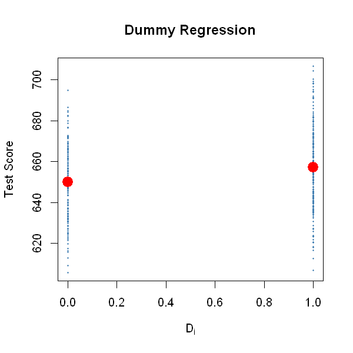

```r
# Plot the data
plot(df$D, df$score,            # provide the data to be plotted
     pch = 20,                                # use filled circles as plot symbols
     cex = 0.5,                               # set size of plot symbols to 0.5
     col = "Steelblue",                       # set the symbols' color to "Steelblue"
     xlab = expression(D[i]),                 # Set title and axis names
     ylab = "Test Score",
     main = "Dummy Regression")

points(x = df$D,
       y = predict(dummy_model),
       col = "red",
       cex = 3,
       pch = 20)
```

```r
# confidence intervals for coefficients in the dummy regression model
confint(dummy_model)
```

|  | 2.5 % | 97.5 % |
| --- | --- | --- |
| (Intercept) | 647.338594 | 652.81500 |
| DTRUE | 3.539562 | 10.79931 |

We reject the hypothesis that there is no difference between group means at the $5 \%$ significance level since $\beta_{1,0}=0$ lies outside of $[3.54,10.8]$, the $95 \%$ confidence interval for the coefficient on $D$.